# Create Calendar Denominators

```r
library(tidyverse)
library(arrow)
library(dtplyr)

source(here::here('functions/fxn_dt_base.R'))
source(here::here('functions/fxn_denominator_eligibility.R'))
source(here::here('functions/fxn_standardize_cow_breed.R'))
source(here::here('functions/fxn_assign_day_of_phase_group.R'))

fxn_add_dop<-function(df){
    df%>%
      left_join(dim_cuts_complete, relationship = "many-to-many")%>%
    filter(!(day_of_phase_start>dop_end))%>%
    filter(!(day_of_phase_end<dop_start))%>%
    mutate(dop_complete  = case_when(
      (dop_start>=day_of_phase_start)&(dop_end<=day_of_phase_end)~'complete',
      TRUE~'incomplete'
    ))
  }

fxn_summarize_deno<-function(df){
    df%>%
      summarize(ct_animal_days_elig = sum(elig_days),
              ct_animals = n_distinct(id_animal),
              ct_animal_lactations = n_distinct(id_animal_lact))%>%
    ungroup()|>
    mutate(days_in_time_period = as.numeric(date_ref_end-date_ref_start))%>%
    mutate(ct_animal_time_periods = ct_animal_days_elig/days_in_time_period)
  }
```

## Read in the Base Data

Denominators are created from animals.parquet, animal_lactations.parquet, and a few parameters from events.parquet

```r
#denominator base files -------------------
animals<-read_parquet(here::here('data/intermediate_files/animals.parquet')) #each row is an animal

animal_lactations<-read_parquet(here::here('data/intermediate_files/animal_lactations.parquet')) #each row is an animal lactation

animal_event_existance<-read_parquet(here::here('data/intermediate_files/events_all_columns.parquet'))%>% #add a few parameters to animal
  mutate(lact = parse_number(LACT))%>%
  group_by(id_animal)%>%
  summarize(
            animal_lact_min = min(lact),
            animal_lact_max = max(lact),
            animal_date_event_min = min(date_event, na.rm = TRUE),
            animal_date_event_max = max(date_event, na.rm = TRUE))%>%
  ungroup()


#---------------------------
data_pull_min<-min(animals$data_pull_date_min)
data_pull_max<-max(animals$data_pull_date_max)
```

## Active animals

This section displays the active animals. This is a good place to check that the counts make sense.

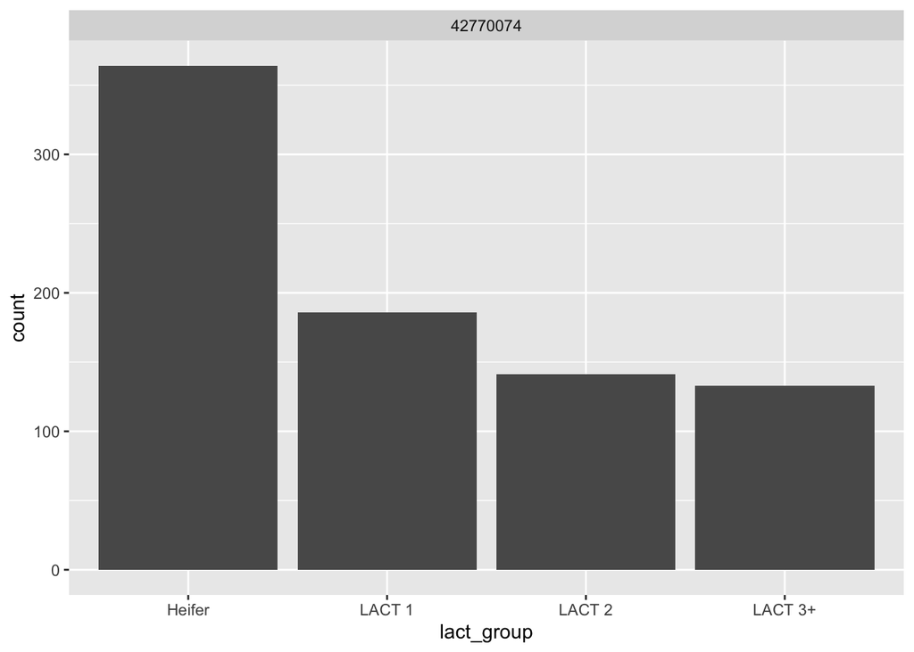

```r
active_animals<-animal_lactations%>%
  filter(animal_lactation_status %in% 'active')

ggplot(active_animals)+
  geom_bar(aes(x = lact_group))+
  facet_wrap(location_lact_last~.)
```

## Define calendar days for calculations

```r
get_bookend<-max(animal_event_existance$animal_date_event_max)

calendar_granular<-tibble(date_calendar = seq.Date(get_bookend, (get_bookend-1500), by = -1))

fxn_create_calendar_summary<-function(time_period_type = 'month'){
  calendar_granular%>%
  mutate(calendar_period_type = time_period_type,
         calendar_period = floor_date(date_calendar, unit = time_period_type) )%>%
  group_by(calendar_period_type, calendar_period)%>%
  summarize(date_time_period_end = max(date_calendar),
            date_time_period_start = min(date_calendar))%>%
  ungroup()%>%
  mutate(days_in_period = (date_time_period_end-date_time_period_start)+1)%>%
    select(calendar_period_type, calendar_period, contains('date'), days_in_period)
}

#-------------------------

calendar_years<-fxn_create_calendar_summary(time_period_type = 'year')
#calendar_halfyears<-fxn_create_calendar_summary(time_period_type = 'halfyear')
calendar_seasons<-fxn_create_calendar_summary(time_period_type = 'season')
#calendar_bimonth<-fxn_create_calendar_summary(time_period_type = 'bimonth')
calendar_months<-fxn_create_calendar_summary(time_period_type = 'month')
#calendar_weeks<-fxn_create_calendar_summary(time_period_type = 'week')


#------------------------------
calendar <-bind_rows(calendar_years, #calendar_halfyears,
                     calendar_seasons, #calendar_bimonth,
                     calendar_months#, calendar_weeks
                     )%>%
  mutate(date_calendar = date_time_period_start)
write_parquet(calendar, here::here('data/intermediate_files/calendar_from_calender_time_periods.parquet'))
```

## Define the list of animals

This is the base data for denominator calculations.  
Each row is a unique animal lactation (id_animal_lact), from the `animal_lactations.parquet` file. This is then joined to the animal data (`animals.parquet`) to make sure all dates for eligibility are available if needed.

In this base version of denominators, an animal is eligible to be counted if she exists on the reference day. You can modify this if you choose. There are example functions for all_lactation, milking, dry. Code can easily be modified to accept other eligibility criteria.

```r
#base data frame for denominator.  Each row is an animal lactation, joined to animal data so that all important dates are available
deno_base<-animal_lactations |>
  left_join(animals) %>%
  left_join(animal_event_existance)

deno_all_lact<-deno_base%>%
  fxn_deno_eligible_entire_lactation() #animals are eligible the entire lactation

deno_milking<-deno_base%>%
  fxn_deno_eligible_milking() #animals are eligible only when milking

deno_dry<-deno_base%>%
  fxn_deno_eligible_dry() #animals are eligible only when dry
```

### set base type used for calculations

Turn on only one of these lines in this chunk

```r
set_deno_base_type<-deno_all_lact #any animal is eligible
#set_deno_base_type<-deno_milking #only milking animals are eligible
#set_deno_base_type<-deno_dry #only dry animals are eligible
```

## Create cut points for day of phase

The values for the cut points come from the initial set up in step 0. You should modify the values there, not within this script.

```r
 dim_cuts<-tibble(dop_start = c(-Inf, seq(0, params$top_cut, by = params$cut_by_days)))%>%
             mutate(dop_end = case_when(
               (dop_start == (-Inf))~(-1),
               dop_start == max(dop_start)~Inf,
               TRUE~ dop_start + (params$cut_by_days-1))
               )%>%
             mutate(dop_in_interval = (dop_end-dop_start)+1)

age_cuts<-tibble(dop_start = c(-Inf, seq(0, params$top_cut_hfr, by = params$cut_by_days)))%>%
             mutate(dop_end = case_when(
               (dop_start == (-Inf))~(-1),
               dop_start == max(dop_start)~Inf,
               TRUE~ dop_start + (params$cut_by_days-1))
               )%>%
             mutate(dop_in_interval = (dop_end-dop_start)+1)%>%
             mutate(lact_number = 0)
```

## Count cows on each calendar day for different lacation groups

Mulitple denominator metrics are generated.

- animal days (`ct_animal_days_eligible`) - total animal days eligible within the time_period
- animal time_periods (`ct_animal_time_periods`) - animal days / number of days in time_period
- animals (`ct_animals`) - number of animals with at least 1 day eligible within the time_period
- animal lactations (`ct_animal_lactations`) - number of animal lactations with at least one day eligible within the time_period

These values are calculated for each lactation group within the time_period, as well as for each dim group within lactation group. (see section below on denominator types)